# **PLSC - Political Science Poli.Analysis & Data w/ Python**

## **Summer 2023**

### Module 3

# **Pandas**

`Pandas` stands for *Python Data Analysis Library*.

This library is the most important library for data analysis.

Mastering `pandas` is an important skill that you should have.

Once you learn pandas you will not need excel anymore!

`pandas` allows us to work with dataframes.

It is built for working structured and tabular data like excel or csv files.

Pandas is used in data science, machine learning, and business analytics for tasks such as data cleaning, data wrangling, exploratory data analysis (EDA), and data visualization.

## Here are the things you could do with pandas

- Data import export
- Data Cleaning and Preprocessing
- Data Aggregation and Grouping
- Data Visualization

## Best resource for mastering pandas is this book:

It is written by Pandas's creator, Wes McKinney.

You can access the book for **free** from this [link](https://wesmckinney.com/book/).

Feel free to buy a paper copy if you want.

[figure not shown]

As always, look at the documentation from [here](https://pandas.pydata.org/) for more information about what you can do with pandas.

Lastly, there has been recent development for data analysis using Python. `Polars` is a package built on top of pandas but faster than pandas. If you ever have very large datasets `polars` can handle much more quickly. But for now, I would recommend you to stick with pandas. Learn pandas first. More on `polars`, [here](https://www.pola.rs/).

## Let's start!

Note that we cannot cover all the functions of pandas library.

I will mostly cover the most common and useful methods in pandas. To learn more, read the book, read the documentation, Youtube is also a great resource.

```python
# to start using pandas, we have to first request pandas.
# Notice alias pd. We do not write pandas over and over again

import pandas as pd
```

## Introduction to Pandas

- Series
- DataFrames
- Missing Data
- GroupBy
- Merging,Joining,and Concatenating
- Operations
- Data Input and Output

### Series

The first main data type we will learn about for pandas is the Series data type.

Very similar to a NumPy array.

Series can have axis labels such as variable names. Numpy array did not have that.

```python
import numpy as np
```

```python
# creating data

labels = ['a','b','c'] #list

my_list = [10,20,30] #list

arr = np.array([10,20,30]) #array

dictionary = {'a':10,'b':20,'c':30} #dictionary
```

```python
# from list to series

pd.Series(data=my_list)
```

```
0    10
1    20
2    30
dtype: int64
```

```python
pd.Series(data=my_list,index=labels)
```

```
a    10
b    20
c    30
dtype: int64
```

```python
# from array to series

pd.Series(arr,labels)
```

```
a    10
b    20
c    30
dtype: int64
```

```python
# from dictonary

pd.Series(dictionary)
```

```
a    10
b    20
c    30
dtype: int64
```

## Index in pandas

The key to using a Series is understanding its index.

```python
ser1 = pd.Series([1,2,3,4],index = ['USA', 'Germany','Mexico', 'S.Korea'])

ser1
```

```
USA        1
Germany    2
Mexico     3
S.Korea    4
dtype: int64
```

```python
ser2 = pd.Series([1,2,5,4],index = ['USA', 'Germany','Iran', 'Turkey'])

ser2
```

```
USA        1
Germany    2
Iran       5
Turkey     4
dtype: int64
```

```python
ser1['USA']
```

```
1
```

```python
ser2['Turkey']
```

```
4
```

## DataFrame

DataFrame is a excel-like tabular data structure.

It is combination of Series that share the same index.

Think of a database of students, their age, gender, school, gpa, major etc.

```python
# lets create a fake data using numpy random
from numpy.random import randn
# see we do not have to import all numpy.
# We can also use from to import only a spesific method from a library

df = pd.DataFrame(randn(5,4),index='A B C D E'.split(),columns='W X Y Z'.split())

df
```

|  | W | X | Y | Z |
| --- | --- | --- | --- | --- |
| A | -2.418629 | 1.916302 | 0.172458 | -0.108146 |
| B | 1.414011 | 1.032227 | 1.665910 | -1.822575 |
| C | -2.484369 | -0.131171 | -0.464459 | 2.537180 |
| D | 1.842366 | -0.196282 | 0.378416 | -0.466926 |
| E | 1.398043 | -1.132830 | 2.386520 | -1.936298 |

```python
df1 = pd.DataFrame(randn(5,4),index=list('abcde'),columns=list('wxyz'))

df1
```

|  | w | x | y | z |
| --- | --- | --- | --- | --- |
| a | -1.563190 | 1.739644 | 0.814939 | 0.733371 |
| b | -0.485150 | 0.520580 | 0.025640 | -0.791674 |
| c | -0.489112 | 1.899308 | -0.258522 | -0.649231 |
| d | -1.104522 | -0.368799 | 1.018791 | 1.677093 |
| e | 1.610636 | -0.466732 | -0.442956 | -0.483374 |

```python
list('abcde')
```

```
['a', 'b', 'c', 'd', 'e']
```

```python
'A B C D E'.split()
```

```
['A', 'B', 'C', 'D', 'E']
```

```python
df
```

|  | W | X | Y | Z |
| --- | --- | --- | --- | --- |
| A | -2.418629 | 1.916302 | 0.172458 | -0.108146 |
| B | 1.414011 | 1.032227 | 1.665910 | -1.822575 |
| C | -2.484369 | -0.131171 | -0.464459 | 2.537180 |
| D | 1.842366 | -0.196282 | 0.378416 | -0.466926 |
| E | 1.398043 | -1.132830 | 2.386520 | -1.936298 |

```python
df['W']
```

```
A   -2.418629
B    1.414011
C   -2.484369
D    1.842366
E    1.398043
Name: W, dtype: float64
```

```python
# alternative Syntax (do not use, it can be confusing)
df.W
```

```
A   -2.418629
B    1.414011
C   -2.484369
D    1.842366
E    1.398043
Name: W, dtype: float64
```

```python
# Pass a list of column names
df[['W','Z']]
```

|  | W | Z |
| --- | --- | --- |
| A | -2.418629 | -0.108146 |
| B | 1.414011 | -1.822575 |
| C | -2.484369 | 2.537180 |
| D | 1.842366 | -0.466926 |
| E | 1.398043 | -1.936298 |

```python
type(df)
```

```
pandas.core.frame.DataFrame
```

```python
type(df['W'])
```

```
pandas.core.series.Series
```

```python
#create a new column

df['new'] = df['W'] + df['Y']

df
```

|  | W | X | Y | Z | new |
| --- | --- | --- | --- | --- | --- |
| A | -2.418629 | 1.916302 | 0.172458 | -0.108146 | -2.246171 |
| B | 1.414011 | 1.032227 | 1.665910 | -1.822575 | 3.079921 |
| C | -2.484369 | -0.131171 | -0.464459 | 2.537180 | -2.948828 |
| D | 1.842366 | -0.196282 | 0.378416 | -0.466926 | 2.220781 |
| E | 1.398043 | -1.132830 | 2.386520 | -1.936298 | 3.784563 |

```python
#remove a column

df.drop('new',axis=1)

df #so did not drop, because we need to use inplace=True
```

|  | W | X | Y | Z | new |
| --- | --- | --- | --- | --- | --- |
| A | -2.418629 | 1.916302 | 0.172458 | -0.108146 | -2.246171 |
| B | 1.414011 | 1.032227 | 1.665910 | -1.822575 | 3.079921 |
| C | -2.484369 | -0.131171 | -0.464459 | 2.537180 | -2.948828 |
| D | 1.842366 | -0.196282 | 0.378416 | -0.466926 | 2.220781 |
| E | 1.398043 | -1.132830 | 2.386520 | -1.936298 | 3.784563 |

```python
df.drop('new',axis=1,inplace=True)

df
```

|  | W | X | Y | Z |
| --- | --- | --- | --- | --- |
| A | -2.418629 | 1.916302 | 0.172458 | -0.108146 |
| B | 1.414011 | 1.032227 | 1.665910 | -1.822575 |
| C | -2.484369 | -0.131171 | -0.464459 | 2.537180 |
| D | 1.842366 | -0.196282 | 0.378416 | -0.466926 |
| E | 1.398043 | -1.132830 | 2.386520 | -1.936298 |

```python
#drop a row

df.drop('E',axis=0, inplace=True)

df
```

|  | W | X | Y | Z |
| --- | --- | --- | --- | --- |
| A | -2.418629 | 1.916302 | 0.172458 | -0.108146 |
| B | 1.414011 | 1.032227 | 1.665910 | -1.822575 |
| C | -2.484369 | -0.131171 | -0.464459 | 2.537180 |
| D | 1.842366 | -0.196282 | 0.378416 | -0.466926 |

### Using loc and iloc for location of rows

```python
# select row using loc method based on labels

df.loc['A']
```

```
W   -2.418629
X    1.916302
Y    0.172458
Z   -0.108146
Name: A, dtype: float64
```

```python
# select row based on index position using loc
df.iloc[2]
```

```
W   -2.484369
X   -0.131171
Y   -0.464459
Z    2.537180
Name: C, dtype: float64
```

```python
#Selecting subset of rows and columns

df.loc['B','Y']
```

```
1.6659101298910926
```

```python
df.loc[['A','B'],['W','Y']]
```

|  | W | Y |
| --- | --- | --- |
| A | -2.418629 | 0.172458 |
| B | 1.414011 | 1.665910 |

### Conditional Selection

Using bracket notation, very similar to numpy

```python
df
```

|  | W | X | Y | Z |
| --- | --- | --- | --- | --- |
| A | -2.418629 | 1.916302 | 0.172458 | -0.108146 |
| B | 1.414011 | 1.032227 | 1.665910 | -1.822575 |
| C | -2.484369 | -0.131171 | -0.464459 | 2.537180 |
| D | 1.842366 | -0.196282 | 0.378416 | -0.466926 |

```python
df>0
```

|  | W | X | Y | Z |
| --- | --- | --- | --- | --- |
| A | False | True | True | False |
| B | True | True | True | False |
| C | False | False | False | True |
| D | True | False | True | False |

```python
df[df>0]
```

|  | W | X | Y | Z |
| --- | --- | --- | --- | --- |
| A | NaN | 1.916302 | 0.172458 | NaN |
| B | 1.414011 | 1.032227 | 1.665910 | NaN |
| C | NaN | NaN | NaN | 2.53718 |
| D | 1.842366 | NaN | 0.378416 | NaN |

```python
df[df['W']>0]
```

|  | W | X | Y | Z |
| --- | --- | --- | --- | --- |
| B | 1.414011 | 1.032227 | 1.665910 | -1.822575 |
| D | 1.842366 | -0.196282 | 0.378416 | -0.466926 |

```python
df[df['W']>0]['Y']
```

```
B    1.665910
D    0.378416
Name: Y, dtype: float64
```

```python
#For two conditions you can use | & within parenthesis:

df[(df['W']>0) & (df['Y'] > 0)]
```

|  | W | X | Y | Z |
| --- | --- | --- | --- | --- |
| B | 1.414011 | 1.032227 | 1.665910 | -1.822575 |
| D | 1.842366 | -0.196282 | 0.378416 | -0.466926 |

## More on Index

Let's discuss resetting the index or setting it something else and multi-index.

```python
df = pd.DataFrame(randn(5,4),index='A B C D E'.split(),columns='W X Y Z'.split())

df
```

|  | W | X | Y | Z |
| --- | --- | --- | --- | --- |
| A | -1.973559 | -1.314003 | 1.734659 | 1.810552 |
| B | -0.398500 | -1.368857 | 0.030456 | 0.062883 |
| C | 0.152727 | 0.836325 | 0.804829 | -1.502980 |
| D | -0.044544 | 1.620835 | 0.217308 | 0.868609 |
| E | -0.264379 | -1.476626 | -2.097886 | -0.259578 |

```python
# Reset
df.reset_index()
```

|  | index | W | X | Y | Z |
| --- | --- | --- | --- | --- | --- |
| 0 | A | -1.973559 | -1.314003 | 1.734659 | 1.810552 |
| 1 | B | -0.398500 | -1.368857 | 0.030456 | 0.062883 |
| 2 | C | 0.152727 | 0.836325 | 0.804829 | -1.502980 |
| 3 | D | -0.044544 | 1.620835 | 0.217308 | 0.868609 |
| 4 | E | -0.264379 | -1.476626 | -2.097886 | -0.259578 |

```python
newind = 'CA NY WY OR CO'.split() #remember split by default use spaces to split

newind
```

```
['CA', 'NY', 'WY', 'OR', 'CO']
```

```python
df['States'] = newind

df
```

|  | W | X | Y | Z | States |
| --- | --- | --- | --- | --- | --- |
| A | -1.973559 | -1.314003 | 1.734659 | 1.810552 | CA |
| B | -0.398500 | -1.368857 | 0.030456 | 0.062883 | NY |
| C | 0.152727 | 0.836325 | 0.804829 | -1.502980 | WY |
| D | -0.044544 | 1.620835 | 0.217308 | 0.868609 | OR |
| E | -0.264379 | -1.476626 | -2.097886 | -0.259578 | CO |

```python
df.set_index('States')
```

| States | W | X | Y | Z |
| --- | --- | --- | --- | --- |
| CA | -1.973559 | -1.314003 | 1.734659 | 1.810552 |
| NY | -0.398500 | -1.368857 | 0.030456 | 0.062883 |
| WY | 0.152727 | 0.836325 | 0.804829 | -1.502980 |
| OR | -0.044544 | 1.620835 | 0.217308 | 0.868609 |
| CO | -0.264379 | -1.476626 | -2.097886 | -0.259578 |

```python
df
```

|  | W | X | Y | Z | States |
| --- | --- | --- | --- | --- | --- |
| A | -1.973559 | -1.314003 | 1.734659 | 1.810552 | CA |
| B | -0.398500 | -1.368857 | 0.030456 | 0.062883 | NY |
| C | 0.152727 | 0.836325 | 0.804829 | -1.502980 | WY |
| D | -0.044544 | 1.620835 | 0.217308 | 0.868609 | OR |
| E | -0.264379 | -1.476626 | -2.097886 | -0.259578 | CO |

```python
df.set_index('States',inplace=True)
```

```python
df
```

| States | W | X | Y | Z |
| --- | --- | --- | --- | --- |
| CA | -1.973559 | -1.314003 | 1.734659 | 1.810552 |
| NY | -0.398500 | -1.368857 | 0.030456 | 0.062883 |
| WY | 0.152727 | 0.836325 | 0.804829 | -1.502980 |
| OR | -0.044544 | 1.620835 | 0.217308 | 0.868609 |
| CO | -0.264379 | -1.476626 | -2.097886 | -0.259578 |

```python
# Index Levels
outside = ['G1','G1','G1','G2','G2','G2']
inside = [1,2,3,1,2,3]
multi_index = list(zip(outside,inside))
multi_index = pd.MultiIndex.from_tuples(multi_index)

multi_index
```

```
MultiIndex([('G1', 1),
            ('G1', 2),
            ('G1', 3),
            ('G2', 1),
            ('G2', 2),
            ('G2', 3)],
           )
```

```python
df = pd.DataFrame(np.random.randn(6,2),index=multi_index,columns=['A','B'])
df
```

|  |  | A | B |
| --- | --- | --- | --- |
| G1 | 1 | 0.162482 | 0.888721 |
|  | 2 | 1.443108 | 1.219528 |
|  | 3 | -0.286188 | -1.925480 |
| G2 | 1 | -0.064552 | 0.992014 |
|  | 2 | -0.510798 | -0.625972 |
|  | 3 | 0.050151 | -0.612627 |

```python
#Calling one level of the index returns the sub-dataframe
df.loc['G1']
```

|  | A | B |
| --- | --- | --- |
| 1 | 0.162482 | 0.888721 |
| 2 | 1.443108 | 1.219528 |
| 3 | -0.286188 | -1.925480 |

```python
df.loc['G1'].iloc[1]
```

```
A    1.443108
B    1.219528
Name: 2, dtype: float64
```

```python
df.loc['G1'].loc[1]

#notice the difference between iloc and loc.
#iloc is based on index position
#loc is label
```

```
A    0.162482
B    0.888721
Name: 1, dtype: float64
```

```python
df
```

|  |  | A | B |
| --- | --- | --- | --- |
| G1 | 1 | 0.162482 | 0.888721 |
|  | 2 | 1.443108 | 1.219528 |
|  | 3 | -0.286188 | -1.925480 |
| G2 | 1 | -0.064552 | 0.992014 |
|  | 2 | -0.510798 | -0.625972 |
|  | 3 | 0.050151 | -0.612627 |

```python
df.index.names = ['Group','No']

df
```

| Group | No | A | B |
| --- | --- | --- | --- |
| G1 | 1 | 0.162482 | 0.888721 |
|  | 2 | 1.443108 | 1.219528 |
|  | 3 | -0.286188 | -1.925480 |
| G2 | 1 | -0.064552 | 0.992014 |
|  | 2 | -0.510798 | -0.625972 |
|  | 3 | 0.050151 | -0.612627 |

## Handling missing data

```python
df = pd.DataFrame({'A':[1,2,np.nan],
                  'B':[5,np.nan,np.nan],
                  'C':[1,2,3]})

df
```

|  | A | B | C |
| --- | --- | --- | --- |
| 0 | 1.0 | 5.0 | 1 |
| 1 | 2.0 | NaN | 2 |
| 2 | NaN | NaN | 3 |

```python
df.dropna()
```

|  | A | B | C |
| --- | --- | --- | --- |
| 0 | 1.0 | 5.0 | 1 |

```python
df.dropna(axis=1)
```

|  | C |
| --- | --- |
| 0 | 1 |
| 1 | 2 |
| 2 | 3 |

```python
df.dropna(thresh=2)
```

|  | A | B | C |
| --- | --- | --- | --- |
| 0 | 1.0 | 5.0 | 1 |
| 1 | 2.0 | NaN | 2 |

```python
df.fillna(value='hello')
```

|  | A | B | C |
| --- | --- | --- | --- |
| 0 | 1.0 | 5.0 | 1 |
| 1 | 2.0 | hello | 2 |
| 2 | hello | hello | 3 |

```python
df['A'].mean()
```

```
1.5
```

```python
df['A'].fillna(value=df['A'].mean())
```

```
0    1.0
1    2.0
2    1.5
Name: A, dtype: float64
```

## Groupby

Now you can use the `.groupby()` method to group rows together based off of a column name.

```python
# Create dataframe
data = {'Company':['GOOG','GOOG','MSFT','MSFT','FB','FB'],
       'Person':['Sam','Charlie','Amy','Vanessa','Carl','Sarah'],
       'Sales':[200,120,340,124,243,350]}

data
```

```
{'Company': ['GOOG', 'GOOG', 'MSFT', 'MSFT', 'FB', 'FB'],
 'Person': ['Sam', 'Charlie', 'Amy', 'Vanessa', 'Carl', 'Sarah'],
 'Sales': [200, 120, 340, 124, 243, 350]}
```

```python
df = pd.DataFrame(data)

df
```

|  | Company | Person | Sales |
| --- | --- | --- | --- |
| 0 | GOOG | Sam | 200 |
| 1 | GOOG | Charlie | 120 |
| 2 | MSFT | Amy | 340 |
| 3 | MSFT | Vanessa | 124 |
| 4 | FB | Carl | 243 |
| 5 | FB | Sarah | 350 |

```python
df.groupby('Company')
```

```
<pandas.core.groupby.generic.DataFrameGroupBy object at 0x7a438aadada0>
```

```python
by_comp = df.groupby("Company")
```

```python
by_comp.mean()
```

| Company | Sales |
| --- | --- |
| FB | 296.5 |
| GOOG | 160.0 |
| MSFT | 232.0 |

```python
df.groupby('Company').mean()
```

| Company | Sales |
| --- | --- |
| FB | 296.5 |
| GOOG | 160.0 |
| MSFT | 232.0 |

```python
by_comp.std()
```

| Company | Sales |
| --- | --- |
| FB | 75.660426 |
| GOOG | 56.568542 |
| MSFT | 152.735065 |

```python
by_comp.min()
```

| Company | Person | Sales |
| --- | --- | --- |
| FB | Carl | 243 |
| GOOG | Charlie | 120 |
| MSFT | Amy | 124 |

```python
by_comp.count()
```

| Company | Person | Sales |
| --- | --- | --- |
| FB | 2 | 2 |
| GOOG | 2 | 2 |
| MSFT | 2 | 2 |

```python
by_comp.describe()
```

| Company | Sales count | Sales mean | Sales std | Sales min | Sales 25% | Sales 50% | Sales 75% | Sales max |
| --- | --- | --- | --- | --- | --- | --- | --- | --- |
| FB | 2.0 | 296.5 | 75.660426 | 243.0 | 269.75 | 296.5 | 323.25 | 350.0 |
| GOOG | 2.0 | 160.0 | 56.568542 | 120.0 | 140.00 | 160.0 | 180.00 | 200.0 |
| MSFT | 2.0 | 232.0 | 152.735065 | 124.0 | 178.00 | 232.0 | 286.00 | 340.0 |

```python
by_comp.describe().transpose()
```

|  | Company | FB | GOOG | MSFT |
| --- | --- | --- | --- | --- |
| Sales | count | 2.000000 | 2.000000 | 2.000000 |
|  | mean | 296.500000 | 160.000000 | 232.000000 |
|  | std | 75.660426 | 56.568542 | 152.735065 |
|  | min | 243.000000 | 120.000000 | 124.000000 |
|  | 25% | 269.750000 | 140.000000 | 178.000000 |
|  | 50% | 296.500000 | 160.000000 | 232.000000 |
|  | 75% | 323.250000 | 180.000000 | 286.000000 |
|  | max | 350.000000 | 200.000000 | 340.000000 |

```python
by_comp.describe().transpose()['GOOG']
```

```
Sales  count      2.000000
       mean     160.000000
       std       56.568542
       min      120.000000
       25%      140.000000
       50%      160.000000
       75%      180.000000
       max      200.000000
Name: GOOG, dtype: float64
```

## Mergeing

3 main ways of combining DataFrames together:

- Merging
- Joining
- Concatenating

```python
df1 = pd.DataFrame({'A': ['A0', 'A1', 'A2', 'A3'],
                        'B': ['B0', 'B1', 'B2', 'B3'],
                        'C': ['C0', 'C1', 'C2', 'C3'],
                        'D': ['D0', 'D1', 'D2', 'D3']},
                        index=[0, 1, 2, 3])

df1
```

|  | A | B | C | D |
| --- | --- | --- | --- | --- |
| 0 | A0 | B0 | C0 | D0 |
| 1 | A1 | B1 | C1 | D1 |
| 2 | A2 | B2 | C2 | D2 |
| 3 | A3 | B3 | C3 | D3 |

```python
df2 = pd.DataFrame({'A': ['A4', 'A5', 'A6', 'A7'],
                        'B': ['B4', 'B5', 'B6', 'B7'],
                        'C': ['C4', 'C5', 'C6', 'C7'],
                        'D': ['D4', 'D5', 'D6', 'D7']},
                         index=[4, 5, 6, 7])

df2
```

|  | A | B | C | D |
| --- | --- | --- | --- | --- |
| 4 | A4 | B4 | C4 | D4 |
| 5 | A5 | B5 | C5 | D5 |
| 6 | A6 | B6 | C6 | D6 |
| 7 | A7 | B7 | C7 | D7 |

```python
df3 = pd.DataFrame({'A': ['A8', 'A9', 'A10', 'A11'],
                        'B': ['B8', 'B9', 'B10', 'B11'],
                        'C': ['C8', 'C9', 'C10', 'C11'],
                        'D': ['D8', 'D9', 'D10', 'D11']},
                        index=[8, 9, 10, 11])

df3
```

|  | A | B | C | D |
| --- | --- | --- | --- | --- |
| 8 | A8 | B8 | C8 | D8 |
| 9 | A9 | B9 | C9 | D9 |
| 10 | A10 | B10 | C10 | D10 |
| 11 | A11 | B11 | C11 | D11 |

```python
#Concatenation basically glues together DataFrames

pd.concat([df1,df2,df3])
```

|  | A | B | C | D |
| --- | --- | --- | --- | --- |
| 0 | A0 | B0 | C0 | D0 |
| 1 | A1 | B1 | C1 | D1 |
| 2 | A2 | B2 | C2 | D2 |
| 3 | A3 | B3 | C3 | D3 |
| 4 | A4 | B4 | C4 | D4 |
| 5 | A5 | B5 | C5 | D5 |
| 6 | A6 | B6 | C6 | D6 |
| 7 | A7 | B7 | C7 | D7 |
| 8 | A8 | B8 | C8 | D8 |
| 9 | A9 | B9 | C9 | D9 |
| 10 | A10 | B10 | C10 | D10 |
| 11 | A11 | B11 | C11 | D11 |

```python
pd.concat([df1,df2,df3],axis=1)
```

|  | A | B | C | D | A | B | C | D | A | B | C | D |
| --- | --- | --- | --- | --- | --- | --- | --- | --- | --- | --- | --- | --- |
| 0 | A0 | B0 | C0 | D0 | NaN | NaN | NaN | NaN | NaN | NaN | NaN | NaN |
| 1 | A1 | B1 | C1 | D1 | NaN | NaN | NaN | NaN | NaN | NaN | NaN | NaN |
| 2 | A2 | B2 | C2 | D2 | NaN | NaN | NaN | NaN | NaN | NaN | NaN | NaN |
| 3 | A3 | B3 | C3 | D3 | NaN | NaN | NaN | NaN | NaN | NaN | NaN | NaN |
| 4 | NaN | NaN | NaN | NaN | A4 | B4 | C4 | D4 | NaN | NaN | NaN | NaN |
| 5 | NaN | NaN | NaN | NaN | A5 | B5 | C5 | D5 | NaN | NaN | NaN | NaN |
| 6 | NaN | NaN | NaN | NaN | A6 | B6 | C6 | D6 | NaN | NaN | NaN | NaN |
| 7 | NaN | NaN | NaN | NaN | A7 | B7 | C7 | D7 | NaN | NaN | NaN | NaN |
| 8 | NaN | NaN | NaN | NaN | NaN | NaN | NaN | NaN | A8 | B8 | C8 | D8 |
| 9 | NaN | NaN | NaN | NaN | NaN | NaN | NaN | NaN | A9 | B9 | C9 | D9 |
| 10 | NaN | NaN | NaN | NaN | NaN | NaN | NaN | NaN | A10 | B10 | C10 | D10 |
| 11 | NaN | NaN | NaN | NaN | NaN | NaN | NaN | NaN | A11 | B11 | C11 | D11 |

```python
left = pd.DataFrame({'key': ['K0', 'K1', 'K2', 'K3'],
                     'A': ['A0', 'A1', 'A2', 'A3'],
                     'B': ['B0', 'B1', 'B2', 'B3']})

right = pd.DataFrame({'key': ['K0', 'K1', 'K2', 'K3'],
                          'C': ['C0', 'C1', 'C2', 'C3'],
                          'D': ['D0', 'D1', 'D2', 'D3']})
```

```python
left
```

|  | key | A | B |
| --- | --- | --- | --- |
| 0 | K0 | A0 | B0 |
| 1 | K1 | A1 | B1 |
| 2 | K2 | A2 | B2 |
| 3 | K3 | A3 | B3 |

```python
right
```

|  | key | C | D |
| --- | --- | --- | --- |
| 0 | K0 | C0 | D0 |
| 1 | K1 | C1 | D1 |
| 2 | K2 | C2 | D2 |
| 3 | K3 | C3 | D3 |

```python
# use merge. this is my prefer method

pd.merge(left,right,how='inner',on='key')
```

|  | key | A | B | C | D |
| --- | --- | --- | --- | --- | --- |
| 0 | K0 | A0 | B0 | C0 | D0 |
| 1 | K1 | A1 | B1 | C1 | D1 |
| 2 | K2 | A2 | B2 | C2 | D2 |
| 3 | K3 | A3 | B3 | C3 | D3 |

```python
left = pd.DataFrame({'key1': ['K0', 'K0', 'K1', 'K2'],
                     'key2': ['K0', 'K1', 'K0', 'K1'],
                        'A': ['A0', 'A1', 'A2', 'A3'],
                        'B': ['B0', 'B1', 'B2', 'B3']})

right = pd.DataFrame({'key1': ['K0', 'K1', 'K1', 'K2'],
                               'key2': ['K0', 'K0', 'K0', 'K0'],
                                  'C': ['C0', 'C1', 'C2', 'C3'],
                                  'D': ['D0', 'D1', 'D2', 'D3']})
```

```python
left
```

|  | key1 | key2 | A | B |
| --- | --- | --- | --- | --- |
| 0 | K0 | K0 | A0 | B0 |
| 1 | K0 | K1 | A1 | B1 |
| 2 | K1 | K0 | A2 | B2 |
| 3 | K2 | K1 | A3 | B3 |

```python
right
```

|  | key1 | key2 | C | D |
| --- | --- | --- | --- | --- |
| 0 | K0 | K0 | C0 | D0 |
| 1 | K1 | K0 | C1 | D1 |
| 2 | K1 | K0 | C2 | D2 |
| 3 | K2 | K0 | C3 | D3 |

```python
pd.merge(left, right, on=['key1', 'key2'])
```

|  | key1 | key2 | A | B | C | D |
| --- | --- | --- | --- | --- | --- | --- |
| 0 | K0 | K0 | A0 | B0 | C0 | D0 |
| 1 | K1 | K0 | A2 | B2 | C1 | D1 |
| 2 | K1 | K0 | A2 | B2 | C2 | D2 |

```python
pd.merge(left, right, how='outer', on=['key1', 'key2'])
```

|  | key1 | key2 | A | B | C | D |
| --- | --- | --- | --- | --- | --- | --- |
| 0 | K0 | K0 | A0 | B0 | C0 | D0 |
| 1 | K0 | K1 | A1 | B1 | NaN | NaN |
| 2 | K1 | K0 | A2 | B2 | C1 | D1 |
| 3 | K1 | K0 | A2 | B2 | C2 | D2 |
| 4 | K2 | K1 | A3 | B3 | NaN | NaN |
| 5 | K2 | K0 | NaN | NaN | C3 | D3 |

```python
pd.merge(left, right, how='right', on=['key1', 'key2'])
```

|  | key1 | key2 | A | B | C | D |
| --- | --- | --- | --- | --- | --- | --- |
| 0 | K0 | K0 | A0 | B0 | C0 | D0 |
| 1 | K1 | K0 | A2 | B2 | C1 | D1 |
| 2 | K1 | K0 | A2 | B2 | C2 | D2 |
| 3 | K2 | K0 | NaN | NaN | C3 | D3 |

```python
pd.merge(left, right, how='left', on=['key1', 'key2'])
```

|  | key1 | key2 | A | B | C | D |
| --- | --- | --- | --- | --- | --- | --- |
| 0 | K0 | K0 | A0 | B0 | C0 | D0 |
| 1 | K0 | K1 | A1 | B1 | NaN | NaN |
| 2 | K1 | K0 | A2 | B2 | C1 | D1 |
| 3 | K1 | K0 | A2 | B2 | C2 | D2 |
| 4 | K2 | K1 | A3 | B3 | NaN | NaN |

```python
left = pd.DataFrame({'A': ['A0', 'A1', 'A2'],
                     'B': ['B0', 'B1', 'B2']},
                      index=['K0', 'K1', 'K2'])

right = pd.DataFrame({'C': ['C0', 'C2', 'C3'],
                    'D': ['D0', 'D2', 'D3']},
                      index=['K0', 'K2', 'K3'])
```

```python
left
```

|  | A | B |
| --- | --- | --- |
| K0 | A0 | B0 |
| K1 | A1 | B1 |
| K2 | A2 | B2 |

```python
right
```

|  | C | D |
| --- | --- | --- |
| K0 | C0 | D0 |
| K2 | C2 | D2 |
| K3 | C3 | D3 |

```python
left.join(right)
```

|  | A | B | C | D |
| --- | --- | --- | --- | --- |
| K0 | A0 | B0 | C0 | D0 |
| K1 | A1 | B1 | NaN | NaN |
| K2 | A2 | B2 | C2 | D2 |

```python
left.join(right, how='outer')
```

|  | A | B | C | D |
| --- | --- | --- | --- | --- |
| K0 | A0 | B0 | C0 | D0 |
| K1 | A1 | B1 | NaN | NaN |
| K2 | A2 | B2 | C2 | D2 |
| K3 | NaN | NaN | C3 | D3 |

```python
# more info
pd.merge?
```

## Operations with pandas

For more look at the documentation. These are just a few useful methods:

```python
df = pd.DataFrame({'col1':[1,2,3,4],'col2':[444,555,666,444],'col3':['abc','def','ghi','xyz']})
df.head()
```

|  | col1 | col2 | col3 |
| --- | --- | --- | --- |
| 0 | 1 | 444 | abc |
| 1 | 2 | 555 | def |
| 2 | 3 | 666 | ghi |
| 3 | 4 | 444 | xyz |

```python
df.shape
```

```
(4, 3)
```

```python
df.describe()
```

|  | col1 | col2 |
| --- | --- | --- |
| count | 4.000000 | 4.000000 |
| mean | 2.500000 | 527.250000 |
| std | 1.290994 | 106.274409 |
| min | 1.000000 | 444.000000 |
| 25% | 1.750000 | 444.000000 |
| 50% | 2.500000 | 499.500000 |
| 75% | 3.250000 | 582.750000 |
| max | 4.000000 | 666.000000 |

```python
df.info()
```

```
<class 'pandas.core.frame.DataFrame'>
RangeIndex: 4 entries, 0 to 3
Data columns (total 3 columns):
 #   Column  Non-Null Count  Dtype
---  ------  --------------  -----
 0   col1    4 non-null      int64
 1   col2    4 non-null      int64
 2   col3    4 non-null      object
dtypes: int64(2), object(1)
memory usage: 224.0+ bytes
```

```python
df['col2'].unique()
```

```
array([444, 555, 666])
```

```python
df['col2'].value_counts()
```

```
444    2
555    1
666    1
Name: col2, dtype: int64
```

```python
df
```

|  | col1 | col2 | col3 |
| --- | --- | --- | --- |
| 0 | 1 | 444 | abc |
| 1 | 2 | 555 | def |
| 2 | 3 | 666 | ghi |
| 3 | 4 | 444 | xyz |

```python
newdf = df[(df['col1']>2) & (df['col2']==444)]

newdf
```

|  | col1 | col2 | col3 |
| --- | --- | --- | --- |
| 3 | 4 | 444 | xyz |

### Applying Functions

```python
def times2(x):
    return x*2
```

```python
df
```

|  | col1 | col2 | col3 |
| --- | --- | --- | --- |
| 0 | 1 | 444 | abc |
| 1 | 2 | 555 | def |
| 2 | 3 | 666 | ghi |
| 3 | 4 | 444 | xyz |

```python
df['col1'].apply(times2)
```

```
0    2
1    4
2    6
3    8
Name: col1, dtype: int64
```

```python
df['col3'].apply(len)
```

```
0    3
1    3
2    3
3    3
Name: col3, dtype: int64
```

```python
df['col1'].sum()
```

```
10
```

```python
df.sort_values(by='col2') #inplace=False by default
```

|  | col1 | col2 | col3 |
| --- | --- | --- | --- |
| 0 | 1 | 444 | abc |
| 3 | 4 | 444 | xyz |
| 1 | 2 | 555 | def |
| 2 | 3 | 666 | ghi |

```python
df.isnull()
```

|  | col1 | col2 | col3 |
| --- | --- | --- | --- |
| 0 | False | False | False |
| 1 | False | False | False |
| 2 | False | False | False |
| 3 | False | False | False |

```python
# Drop rows with NaN Values
df.dropna()
```

|  | col1 | col2 | col3 |
| --- | --- | --- | --- |
| 0 | 1 | 444 | abc |
| 1 | 2 | 555 | def |
| 2 | 3 | 666 | ghi |
| 3 | 4 | 444 | xyz |

```python
data = {'A':['foo','foo','foo','bar','bar','bar'],
     'B':['one','one','two','two','one','one'],
       'C':['x','y','x','y','x','y'],
       'D':[1,3,2,5,4,1]}

df = pd.DataFrame(data)

df
```

|  | A | B | C | D |
| --- | --- | --- | --- | --- |
| 0 | foo | one | x | 1 |
| 1 | foo | one | y | 3 |
| 2 | foo | two | x | 2 |
| 3 | bar | two | y | 5 |
| 4 | bar | one | x | 4 |
| 5 | bar | one | y | 1 |

```python
df.pivot_table(values='D',index=['A', 'B'],columns=['C'])
```

| A | C B | x | y |
| --- | --- | --- | --- |
| bar | one | 4.0 | 1.0 |
|  | two | NaN | 5.0 |
| foo | one | 1.0 | 3.0 |
|  | two | 2.0 | NaN |

## import data

```python
#from a link

url = 'https://raw.githubusercontent.com/tlemenestrel/GDP_and_Employment_Rates_Prediction/master/Employment_Rates_Prediction.csv'
df = pd.read_csv(url)

df.head()
```

|  | COUNTRY | MANDATORY YEARS OF EDUCATION | PISA | POPULATION | LABOUR FORCE | EMPLOYMENT RATES |
| --- | --- | --- | --- | --- | --- | --- |
| 0 | Argentina | 14 | 395.0 | 44293293 | 18000000 | 42.60 |
| 1 | North Macedonia | 13 | 400.0 | 2103721 | 950800 | 47.40 |
| 2 | Bosnia and Herzegovina | 9 | 402.3 | 3856181 | 1380000 | 43.00 |
| 3 | Costa Rica | 13 | 414.7 | 4930258 | 2229000 | 58.70 |
| 4 | Mexico | 14 | 416.0 | 124574795 | 54510000 | 61.53 |

```python
#import your own data

df= pd.read_csv("/content/example_data.csv")

df.head()
```

|  | Unnamed: 0 | Name | Age | Gender | Grade | Score |
| --- | --- | --- | --- | --- | --- | --- |
| 0 | 0 | James Lee | 18 | Female | C | 92.023343 |
| 1 | 1 | Jane Johnson | 19 | Female | B | 62.568913 |
| 2 | 2 | William Thomas | 25 | Male | C | 74.577114 |
| 3 | 3 | Michael Wilson | 22 | Male | F | 85.344517 |
| 4 | 4 | Emily Smith | 21 | Male | A | 72.310412 |

```python
df= pd.read_csv("/content/example_data.csv", index_col=0)

df.head()
```

|  | Name | Age | Gender | Grade | Score |
| --- | --- | --- | --- | --- | --- |
| 0 | James Lee | 18 | Female | C | 92.023343 |
| 1 | Jane Johnson | 19 | Female | B | 62.568913 |
| 2 | William Thomas | 25 | Male | C | 74.577114 |
| 3 | Michael Wilson | 22 | Male | F | 85.344517 |
| 4 | Emily Smith | 21 | Male | A | 72.310412 |

```python
df.head(15)
```

|  | Name | Age | Gender | Grade | Score |
| --- | --- | --- | --- | --- | --- |
| 0 | James Lee | 18 | Female | C | 92.023343 |
| 1 | Jane Johnson | 19 | Female | B | 62.568913 |
| 2 | William Thomas | 25 | Male | C | 74.577114 |
| 3 | Michael Wilson | 22 | Male | F | 85.344517 |
| 4 | Emily Smith | 21 | Male | A | 72.310412 |
| 5 | Olivia Garcia | 18 | Female | B | 85.093109 |
| 6 | Jane Brown | 22 | Female | B | 67.560286 |
| 7 | Emily Anderson | 25 | Female | F | 60.397388 |
| 8 | Benjamin Thomas | 19 | Female | F | 80.834132 |
| 9 | Michael Smith | 20 | Female | F | 96.773664 |
| 10 | John Smith | 24 | Female | B | 75.530356 |
| 11 | Olivia Davis | 25 | Female | A | 90.965476 |
| 12 | Emily Wilson | 18 | Male | B | 71.914387 |
| 13 | Benjamin Thomas | 19 | Male | B | 62.725537 |
| 14 | James Smith | 18 | Female | A | 97.961411 |

```python
df.tail()
```

|  | Name | Age | Gender | Grade | Score |
| --- | --- | --- | --- | --- | --- |
| 45 | Michael Wilson | 24 | Male | C | 80.502633 |
| 46 | Isabella Lee | 18 | Male | B | 92.997548 |
| 47 | Isabella Garcia | 19 | Male | F | 60.414785 |
| 48 | John Miller | 19 | Male | F | 81.010757 |
| 49 | Jane Anderson | 18 | Male | D | 63.775026 |

```python
df.tail(10)
```

|  | Name | Age | Gender | Grade | Score |
| --- | --- | --- | --- | --- | --- |
| 40 | John Thomas | 25 | Female | F | 67.616348 |
| 41 | James Miller | 21 | Female | A | 70.976272 |
| 42 | Benjamin Wilson | 18 | Female | D | 87.229529 |
| 43 | Michael Anderson | 23 | Female | A | 62.509701 |
| 44 | William Lee | 19 | Male | F | 67.664080 |
| 45 | Michael Wilson | 24 | Male | C | 80.502633 |
| 46 | Isabella Lee | 18 | Male | B | 92.997548 |
| 47 | Isabella Garcia | 19 | Male | F | 60.414785 |
| 48 | John Miller | 19 | Male | F | 81.010757 |
| 49 | Jane Anderson | 18 | Male | D | 63.775026 |

```python
df.shape
```

```
(50, 5)
```

```python
df.describe()
```

|  | Age | Score |
| --- | --- | --- |
| count | 50.000000 | 50.000000 |
| mean | 20.920000 | 78.575375 |
| std | 2.414582 | 11.844550 |
| min | 18.000000 | 60.397388 |
| 25% | 19.000000 | 68.454672 |
| 50% | 21.000000 | 79.048180 |
| 75% | 23.000000 | 89.440148 |
| max | 25.000000 | 99.588051 |

```python
df.info()
```

```
<class 'pandas.core.frame.DataFrame'>
Int64Index: 50 entries, 0 to 49
Data columns (total 5 columns):
 #   Column  Non-Null Count  Dtype
---  ------  --------------  -----
 0   Name    50 non-null     object
 1   Age     50 non-null     int64
 2   Gender  50 non-null     object
 3   Grade   50 non-null     object
 4   Score   50 non-null     float64
dtypes: float64(1), int64(1), object(3)
memory usage: 2.3+ KB
```

```python
df[df['Score']>90]
```

|  | Name | Age | Gender | Grade | Score |
| --- | --- | --- | --- | --- | --- |
| 0 | James Lee | 18 | Female | C | 92.023343 |
| 9 | Michael Smith | 20 | Female | F | 96.773664 |
| 11 | Olivia Davis | 25 | Female | A | 90.965476 |
| 14 | James Smith | 18 | Female | A | 97.961411 |
| 23 | Benjamin Wilson | 21 | Male | B | 92.788722 |
| 24 | William Brown | 23 | Female | C | 90.141730 |
| 26 | John Brown | 21 | Male | D | 99.588051 |
| 29 | Sophia Davis | 21 | Female | A | 90.665459 |
| 30 | James Lee | 23 | Female | F | 90.901074 |
| 31 | Sophia Garcia | 23 | Female | B | 98.267561 |
| 38 | Olivia Garcia | 25 | Male | D | 93.807932 |
| 46 | Isabella Lee | 18 | Male | B | 92.997548 |

```python
df['Gender'].value_counts()
```

```
Female    28
Male      22
Name: Gender, dtype: int64
```

```python
df['Score'].mean()
```

```
78.57537509682251
```

```python
df.loc[df['Score'].idxmin()]
```

```
Name      Emily Anderson
Age                   25
Gender            Female
Grade                  F
Score          60.397388
Name: 7, dtype: object
```

```python
df.loc[df['Score'].idxmax()]['Name']
```

```
'John Brown'
```

```python
df['Name'].value_counts()
```

```
Benjamin Wilson     4
Olivia Garcia       3
John Smith          3
James Lee           2
Benjamin Thomas     2
Olivia Davis        2
Michael Wilson      2
Isabella Lee        1
William Lee         1
Isabella Garcia     1
Michael Anderson    1
Emily Thomas        1
James Miller        1
John Thomas         1
James Anderson      1
Sophia Brown        1
John Miller         1
William Wilson      1
Olivia Miller       1
Sophia Garcia       1
Sophia Davis        1
Sophia Lee          1
Olivia Wilson       1
John Brown          1
Jane Wilson         1
William Brown       1
Jane Johnson        1
Emily Lee           1
Sophia Anderson     1
John Anderson       1
Michael Garcia      1
James Smith         1
Emily Wilson        1
Michael Smith       1
Emily Anderson      1
Jane Brown          1
Emily Smith         1
William Thomas      1
Jane Anderson       1
Name: Name, dtype: int64
```

```python
#create categories based on bins

df['Score_category']=pd.cut(df['Score'], bins=[0, 60, 80, 100], labels=['Low', 'Acceptable', 'High'])
```

```python
df
```

|  | Name | Age | Gender | Grade | Score | Score_category |
| --- | --- | --- | --- | --- | --- | --- |
| 0 | James Lee | 18 | Female | C | 92.023343 | High |
| 1 | Jane Johnson | 19 | Female | B | 62.568913 | Acceptable |
| 2 | William Thomas | 25 | Male | C | 74.577114 | Acceptable |
| 3 | Michael Wilson | 22 | Male | F | 85.344517 | High |
| 4 | Emily Smith | 21 | Male | A | 72.310412 | Acceptable |
| 5 | Olivia Garcia | 18 | Female | B | 85.093109 | High |
| 6 | Jane Brown | 22 | Female | B | 67.560286 | Acceptable |
| 7 | Emily Anderson | 25 | Female | F | 60.397388 | Acceptable |
| 8 | Benjamin Thomas | 19 | Female | F | 80.834132 | High |
| 9 | Michael Smith | 20 | Female | F | 96.773664 | High |
| 10 | John Smith | 24 | Female | B | 75.530356 | Acceptable |
| 11 | Olivia Davis | 25 | Female | A | 90.965476 | High |
| 12 | Emily Wilson | 18 | Male | B | 71.914387 | Acceptable |
| 13 | Benjamin Thomas | 19 | Male | B | 62.725537 | Acceptable |
| 14 | James Smith | 18 | Female | A | 97.961411 | High |
| 15 | Olivia Davis | 18 | Female | B | 85.174036 | High |
| 16 | Michael Garcia | 20 | Female | C | 89.749979 | High |
| 17 | John Anderson | 23 | Male | D | 88.510657 | High |
| 18 | Benjamin Wilson | 22 | Female | D | 81.899295 | High |
| 19 | Sophia Anderson | 22 | Female | F | 60.968458 | Acceptable |
| 20 | Emily Lee | 19 | Male | F | 70.698547 | Acceptable |
| 21 | John Smith | 24 | Female | B | 88.023262 | High |
| 22 | Olivia Wilson | 18 | Male | D | 83.085788 | High |
| 23 | Benjamin Wilson | 21 | Male | B | 92.788722 | High |
| 24 | William Brown | 23 | Female | C | 90.141730 | High |
| 25 | Jane Wilson | 20 | Female | F | 72.899805 | Acceptable |
| 26 | John Brown | 21 | Male | D | 99.588051 | High |
| 27 | Emily Thomas | 18 | Male | B | 67.712003 | Acceptable |
| 28 | Sophia Lee | 18 | Male | B | 70.682676 | Acceptable |
| 29 | Sophia Davis | 21 | Female | A | 90.665459 | High |
| 30 | James Lee | 23 | Female | F | 90.901074 | High |
| 31 | Sophia Garcia | 23 | Female | B | 98.267561 | High |
| 32 | Olivia Garcia | 20 | Female | D | 79.682947 | Acceptable |
| 33 | Olivia Miller | 24 | Male | F | 78.413413 | Acceptable |
| 34 | John Smith | 19 | Female | C | 71.984515 | Acceptable |
| 35 | Benjamin Wilson | 20 | Male | A | 63.904900 | Acceptable |
| 36 | William Wilson | 24 | Male | D | 74.076343 | Acceptable |
| 37 | Sophia Brown | 21 | Female | B | 72.237061 | Acceptable |
| 38 | Olivia Garcia | 25 | Male | D | 93.807932 | High |
| 39 | James Anderson | 22 | Female | C | 61.627815 | Acceptable |
| 40 | John Thomas | 25 | Female | F | 67.616348 | Acceptable |
| 41 | James Miller | 21 | Female | A | 70.976272 | Acceptable |
| 42 | Benjamin Wilson | 18 | Female | D | 87.229529 | High |
| 43 | Michael Anderson | 23 | Female | A | 62.509701 | Acceptable |
| 44 | William Lee | 19 | Male | F | 67.664080 | Acceptable |
| 45 | Michael Wilson | 24 | Male | C | 80.502633 | High |
| 46 | Isabella Lee | 18 | Male | B | 92.997548 | High |
| 47 | Isabella Garcia | 19 | Male | F | 60.414785 | Acceptable |
| 48 | John Miller | 19 | Male | F | 81.010757 | High |
| 49 | Jane Anderson | 18 | Male | D | 63.775026 | Acceptable |

```python
df.info()
```

```
<class 'pandas.core.frame.DataFrame'>
Int64Index: 50 entries, 0 to 49
Data columns (total 6 columns):
 #   Column          Non-Null Count  Dtype
---  ------          --------------  -----
 0   Name            50 non-null     object
 1   Age             50 non-null     int64
 2   Gender          50 non-null     object
 3   Grade           50 non-null     object
 4   Score           50 non-null     float64
 5   Score_category  50 non-null     category
dtypes: category(1), float64(1), int64(1), object(3)
memory usage: 4.6+ KB
```

```python
#save the data as csv in your computer
df.to_csv('give_a_name.csv')
```

```python
file_path ='give_a_name.xlsx'
# Save the DataFrame to an Excel file
df.to_excel(file_path, index=False)
```

```python
# you can read excel, stata and many other file formats
#just read documentation for that when you need.

df=pd.read_excel('sample_data.xlsx')

df
```

|  | Name | Age | Score |
| --- | --- | --- | --- |
| 0 | John | 25 | 85 |
| 1 | Jane | 22 | 90 |
| 2 | Michael | 28 | 78 |
| 3 | Emily | 24 | 88 |
| 4 | William | 30 | 92 |

### pandas can visualize too

It uses matplotlib library, which we will see next week.

For quick plots you can use pandas as well.

```python
df= pd.read_csv("/content/example_data.csv", index_col=0)

df.head()
```

|  | Name | Age | Gender | Grade | Score |
| --- | --- | --- | --- | --- | --- |
| 0 | James Lee | 18 | Female | C | 92.023343 |
| 1 | Jane Johnson | 19 | Female | B | 62.568913 |
| 2 | William Thomas | 25 | Male | C | 74.577114 |
| 3 | Michael Wilson | 22 | Male | F | 85.344517 |
| 4 | Emily Smith | 21 | Male | A | 72.310412 |

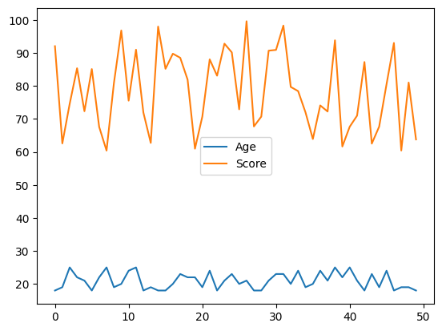

```python
df.plot()
```

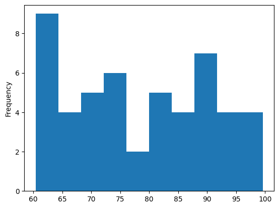

```python
df['Score'].plot(kind='hist')
```

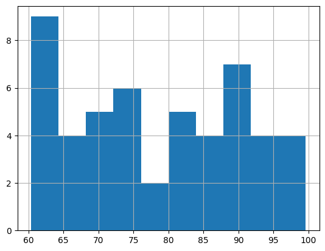

```python
df['Score'].hist()
```

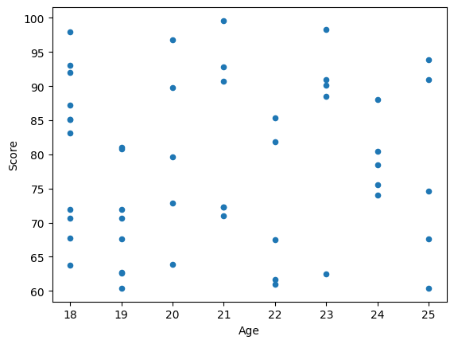

```python
df.plot(x='Age', y='Score', kind='scatter')
```

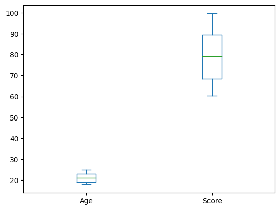

```python
df.plot.box()
```

## Pandas is not over.

There are simply too many things about pandas that we cannot cover here. You would need to search for methods based on your needs and tasks.